# ASCII encoding

**hexadecimal dump of ascii charaters**

from `man ascii`

The control characters in ASCII still in common use include:

- `0x00 (null, NUL, \0, ^@)`, originally intended to be an ignored character, but now used by many programming languages including C to mark the end of a string.
- `0x07 (bell, BEL, \a, ^G)`, which may cause the device to emit a warning such as a bell or beep sound or the screen flashing.
- `0x08 (backspace, BS, \b, ^H)`, may overprint the previous character.
- `0x09 (horizontal tab, HT, \t, ^I)`, moves the printing position right to the next tab stop.
- `0x0A (line feed, LF, \n, ^J)`, moves the print head down one line, or to the left edge and down. Used as the end of line marker in most UNIX systems and variants.
- `0x0B (vertical tab, VT, \v, ^K)`, vertical tabulation.
- `0x0C (form feed, FF, \f, ^L)`, to cause a printer to eject paper to the top of the next page, or a video terminal to clear the screen.
- `0x0D (carriage return, CR, \r, ^M)`, moves the printing position to the start of the line, allowing overprinting. Used as the end of line marker in Classic Mac OS, OS-9, FLEX (and variants). A CR+LF pair is used by CP/M-80 and its derivatives including DOS and Windows, and by Application Layer protocols such as FTP, SMTP, and HTTP.
- `0x1A (Control-Z, SUB, ^Z)`, Acts as an end-of-file for the Windows text-mode file i/o.
- `0x1B (escape, ESC, \e (GCC only), ^[)`. Introduces an escape sequence.
- Control characters may be described as doing something when the user inputs them, such as code 3 (End-of-Text character, ETX, ^C) to interrupt the running process, or code 4 (End-of-Transmission character, EOT, ^D), used to end text input on Unix or to exit a Unix shell. These uses usually have little to do with their use when they are in text being output.

**to see the hex value for characters**

`od -t a -t x1 -t c`

- `-t a` - prints in ascii format
- `-t x1` - prints in hex format
- `-t c` - prints in c escape format

e.g.

```
> printf '\0\a\b\n\r\t\v ' | od -t a -t x1 -t c
0000000  nul bel  bs  nl  cr  ht  vt  sp
          00  07  08  0a  0d  09  0b  20
          \0  \a  \b  \n  \r  \t  \v
0000010
```

**Understanding the color escape code**

`\033` is actually ESC character in ascii octal format, `\e` is equivalent in zsh shell, however, don’t use `\e`, `\e` is not recognised in `awk` nor `python`.

```
> echo "\033[31mRed Text\033[0m"
Red Text
> echo "\e[31mRed Text\e[0m"
Red Text
```

- `\033[` - Begin the color modifications
- `CODEm` - CODE + `m` at the end
- `\e[0m` - End the color modifications

| code | description |
| --- | --- |
| `30` | fg black |
| `31` | fg red |
| `32` | fg green |
| `33` | fg brown |
| `34` | fg blue |
| `35` | fg purple |
| `36` | fg cyan |
| `37` | fg light grey |
| `40` | bg black |
| `41` | bg red |
| `42` | bg green |
| `43` | bg brown |
| `44` | bg blue |
| `45` | bg purple |
| `46` | bg cyan |
| `47` | bg light grey |
| `0` | reset / normal |
| `1` | bold |
| `3` | italic |
| `4` | underline |

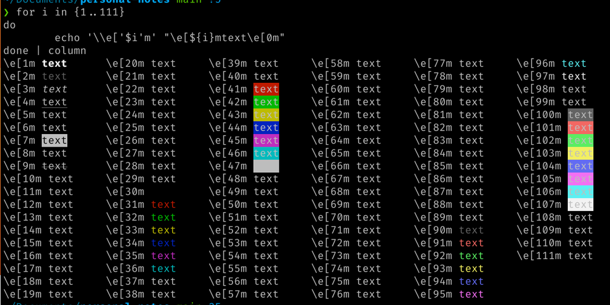

bash color

```bash
> for i in {1..111}
do
    echo '\\e['$i'm' "\e[${i}mtext\e[0m"
done | column
```